# Predicting Winning Dota 2 Side With Minimal Features

### Introduction

Dota 2 is a MOBA arena style game where two teams of five fight to destroy the others base. Players play as one of over 100 heroes and work as a team to , collect gold, conquer objectives, and kill the enemy team.

More information on dota 2 and its mechanics can be found here: http://blog.dota2.com

In this tutorial I attempt to determine the winning side of a game as early on as possible in a game. We start with Data available before the game begins and progressively add more revealing information available at later times in a game. This helps to determine the magnitude various actions in-game have on the result of the match.

```python
!pip install sklearn
import requests as r
import pandas as pd
import numpy as np
import ast
from sklearn.utils import shuffle
import matplotlib.pyplot as plt
from sklearn.neighbors import KNeighborsClassifier
from sklearn.model_selection import cross_val_score
import json
```

```
You are using pip version 18.0, however version 18.1 is available.
```

```python
df = pd.read_csv('./FullMatchData3.csv',sep='\t')
df = df.drop_duplicates(subset='match_id')
df = df.loc[df['error']!='rate limit exceeded']
mdf = pd.read_csv('./PublicMatchData3.csv',sep='\t')
df = shuffle(df)
mdf = shuffle(mdf)
print(mdf.head())
print(df.head())
print(len(df))
```

```
      Unnamed: 0  Unnamed: 0.1  Unnamed: 0.1.1  avg_mmr  avg_rank_tier  \
3136          74           NaN             NaN   1354.0             32
1071        1071        1071.0            20.0    921.0             28
2179          30           NaN             NaN   4902.0             73
5540          55           NaN             NaN   2799.0             47
2870           6           NaN             NaN    918.0             44

      cluster        dire_team  duration  game_mode  lobby_type    match_id  \
3136      153     44,70,5,8,17      2659         22           7  4269237014
1071      153    17,75,14,6,47      2578         22           7  4269274902
2179      133   27,14,29,22,41      1568         22           7  4269254106
5540      227   22,44,76,7,110      3156         22           7  4269193303
2870      186  26,121,65,93,62      1570         22           7  4269241504

      match_seq_num  num_mmr  num_rank_tier     radiant_team  radiant_win  \
```

[output cut: 63 more lines]

```
import requests as r
import pandas as pd
url = 'https://api.opendota.com/api/publicMatches'
matchFrame = pd.read_csv('./publicMatchData2.csv',sep='\t')
#res = r.get(url)
#df = pd.read_json(res.text)
#df = df.loc[df['game_mode'] ==22]
#df = df.dropna()
#matchFrame = matchFrame.append(df)
minId = matchFrame['match_id'].min()
for i in range(50):
    res = r.get(url+'?less_than_match_id=' +str(minId))
    df = pd.read_json(res.text)
    df = df.loc[df['game_mode'] ==22]
    df = df.dropna()
    matchFrame = matchFrame.append(df)
    minId = matchFrame['match_id'].min()
matchFrame.to_csv('./publicMatchData3.csv', sep='\t', encoding='utf-8')
```

```
import requests as r
import pandas as pd
import time
df = pd.read_csv('./publicMatchData3.csv',sep='\t')
mdf = pd.read_csv('./FullMatchData2.csv',sep='\t')
knownIds = mdf['match_id'].tolist()
count = 0
try:
    for i, row in df.iterrows():
        matchId = row['match_id']
        if matchId in knownIds:
            print('known match')
        else:
            count+=1
            rUrl = 'https://api.opendota.com/api/matches/' + str(matchId)
            mRes = r.get(rUrl)
            Mdf = mdf.from_dict(mRes.json(),orient='index')
            mdf = mdf.append(Mdf.T)
            if count % 55 ==0:
                print('sleeping ' + str(i))
                time.sleep(60)
except Exception as e:
    print(e)
    print('network lost')
    mdf.to_csv("./Failsafe.csv",sep='\t')
mdf.to_csv('./FullMatchData3.csv', sep='\t',mode='a', encoding='utf-8')
```

### Acquiring data

Data is aquired using the OpenDota API detailed here: https://www.opendota.com

It is clear above that the retrieved data is quite messy and missing many values

The data was fetched in seperate python scripts because the API was unstable with a maximum request limit of 60/min

First we retrieve random public match data followed by a query for more detailed Match information including individiual player performance

```python
def CreateHeroDict():
    heroes = dict()
    for i in range(125):
        heroes[i] = 0
    return heroes
```

### HeroDict

This Dict is used to map the hero selections of each team

We later vectorize the dict to use in our classifier

```python
fdf = pd.DataFrame()
WinningSide = []
X = []
rad_hit = []
op_hit = []
rad_kdas = []
op_kdas = []
radiant_gold_adv = []
for i, row in df.iterrows():
    players = row['players']
    players = ast.literal_eval(players)
    rad_kda = 0
    rad_hits = 0
    rad_gold_adv = 0
    rad_heroes = CreateHeroDict()
    for i,player in enumerate(players[:5]):
        rad_kda += player['kda']
        rad_hits += player['last_hits']
        rad_heroes[player['hero_id']] = 1
        rad_gold_adv += player['gold_spent']

    op_kda = 0
    op_hits = 0
    op_heroes = CreateHeroDict()

    for i,player in enumerate(players[5:]):
        op_kda += player['kda']
        op_hits += player['last_hits']
        op_heroes[player['hero_id']] = 1
        rad_gold_adv -= player['gold_spent']

    temp = []
    temp.append(rad_heroes)
    temp.append(op_heroes)
    X.insert(i,temp)
    rad_hit.insert(i,rad_hits)
    op_hit.insert(i,op_hits)
    radiant_gold_adv.insert(i,rad_gold_adv)
    rad_kdas.insert(i,rad_kda/5)
    op_kdas.insert(i,op_kda/5)


    WinningSide.insert(i,0 if row['radiant_win'] else 1 )
```

### Formatting Data

Above we retrieve the data we want to use for classification later

*_heroes: Is the hero dictionary mapping each teams hero choices

*_hits: The number of minion kills totalled for the team. Minions are small enemies that automatically spawn for each team during the game. A majority of the first 15minutes is spent killing these minions

*_kda: The mean Kill/Death/Assist ration for each team

rad_gold_adv: The total gold advantage of the radiant side at the end of the game (negative values imply that the opposing team has the advatage)

```python
from sklearn.feature_extraction import DictVectorizer
v = DictVectorizer(sparse=False)
XXA = []
for i,x in enumerate(X):
    XXA.insert(i,v.fit_transform(x))
rad_hit = np.array(rad_hit).reshape(len(rad_hit),1)
op_hit = np.array(op_hit).reshape(len(rad_kdas),1)
rad_kdas = np.array(rad_kdas).reshape(len(rad_kdas),1)
op_kdas = np.array(op_kdas).reshape(len(rad_kdas),1)
radiant_gold_adv = np.array(radiant_gold_adv).reshape(len(rad_kdas),1)

temp = np.array(XXA)
XX = temp.transpose(1,2,0).reshape(-1,temp.shape[0]).transpose()
```

Here we finish preparing our data by vectorizing the hero dict and reshaping our other gathered data to concatenate to our features XX later

```python
cv_scores = []
maxN = 100
for k in range(1,maxN,2):
    knn = KNeighborsClassifier(n_neighbors=k)
    scores = cross_val_score(knn, XX, WinningSide, cv=10, scoring='accuracy')
    cv_scores.append(scores.mean())
```

```
The optimal number of neighbors is 99
With Accuracy: 0.551969
```

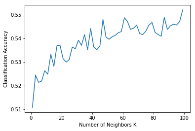

```python
optimal_k = cv_scores.index(max(cv_scores))*2 +1
print ("The optimal number of neighbors is %d" % optimal_k)
print ("With Accuracy: %f" % max(cv_scores))

plt.plot(range(1,maxN,2), cv_scores)
plt.xlabel('Number of Neighbors K')
plt.ylabel('Classification Accuracy')
plt.show()
```

We attempt to classify win/loss using the KNeighbors classifier from sklearn

First We attempt to predict the outcome using only the initial hero choices made before the game begins

Our data sample size severly limits the accuracy of this prediction because there are over 100 heroes and the 5600 match samples obtained cant come close to covering most possible team compositions

Our classification reveals that initial hero choice may play a small role in determining the outcome of the game (even without taking into account individiual players skill level)

```
The optimal number of neighbors is 95
With Accuracy: 0.774081
```

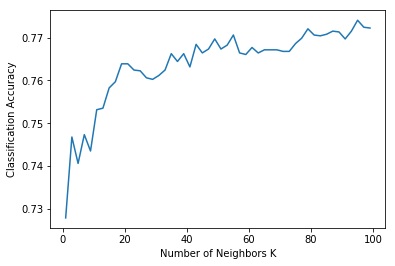

```python
XX = np.concatenate((XX,rad_hit),axis=1)
XX = np.concatenate((XX,op_hit),axis=1)

cv_scores = []
maxN = 100
for k in range(1,maxN,2):
    knn = KNeighborsClassifier(n_neighbors=k)
    scores = cross_val_score(knn, XX, WinningSide, cv=10, scoring='accuracy')
    cv_scores.append(scores.mean())
# determining best k
optimal_k = cv_scores.index(max(cv_scores))*2 +1
print ("The optimal number of neighbors is %d" % optimal_k)
print ("With Accuracy: %f" % max(cv_scores))
# plot misclassification error vs k
plt.plot(range(1,maxN,2), cv_scores)
plt.xlabel('Number of Neighbors K')
plt.ylabel('Classification Accuracy')
plt.show()
```

Now we add each teams minion kill count to the features

Most minion kills occur during laning phase which is early on in the game and usually concludes by the 15minute mark

minion kills are a good indicator of a teams performance during the laning phase

This classification shows that by the conclusion of the laning phase teams the performed better hold a signfigant advantage for winning the game

```
The optimal number of neighbors is 95
With Accuracy: 0.774992
```

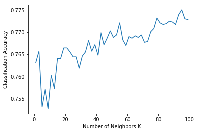

```python
XX = np.concatenate((XX,rad_kdas),axis=1)
XX = np.concatenate((XX,op_kdas),axis=1)

cv_scores = []
for k in range(1,maxN,2):
    knn = KNeighborsClassifier(n_neighbors=k)
    scores = cross_val_score(knn, XX, WinningSide, cv=10, scoring='accuracy')
    cv_scores.append(scores.mean())
# determining best k
optimal_k = cv_scores.index(max(cv_scores))*2 +1
print ("The optimal number of neighbors is %d" % optimal_k)
print ("With Accuracy: %f" % max(cv_scores))
# plot misclassification error vs k
plt.plot(range(1,maxN,2), cv_scores)
plt.xlabel('Number of Neighbors K')
plt.ylabel('Classification Accuracy')
plt.show()
```

Now We attempt to predict the outcome using the average kda for both teams at the end of the game

kda tends to decrease or remain constant as the game progresses and teamfights are more prevelant

This classification was quite surprising. This shows that the kda of a team plays only a minor role in determining victor when compared to each teams performance in the laning phase

```
The optimal number of neighbors is 91
With Accuracy: 0.928453
```

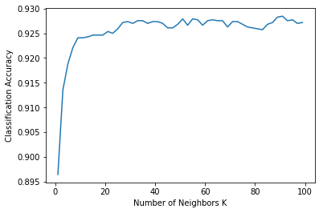

```python
XX = np.concatenate((XX,radiant_gold_adv.reshape(len(radiant_gold_adv),1)),axis=1)

cv_scores = []
maxN = 100
for k in range(1,maxN,2):
    knn = KNeighborsClassifier(n_neighbors=k)
    scores = cross_val_score(knn, XX, WinningSide, cv=10, scoring='accuracy')
    cv_scores.append(scores.mean())
# determining best k
optimal_k = cv_scores.index(max(cv_scores))*2 +1
print ("The optimal number of neighbors is %d" % optimal_k)
print ("With Accuracy: %f" % max(cv_scores))
# plot misclassification error vs k
plt.plot(range(1,maxN,2), cv_scores)
plt.xlabel('Number of Neighbors K')
plt.ylabel('Classification Accuracy')
plt.show()
```

Now we use the total team gold advantage when the game concludes

This classification has the expected results and shows us that in the end the team with the most gold tends to be the victor